# IODS course project

Marc Denojean-Mairet

# Introduction to Open Data Science - Course Project

```r
# This is a so-called "R chunk" where you can write R code.

date()
```

```
## [1] "Sun Nov 28 12:35:40 2021"
```

I am interested in this course because of my research and I am expecting that this course will be a strong introduction to data science. The course should give me enough knowledge to be able to use data science process in my research.

I learned about the course via an email sent to me by my department.

My GitHub repository can be found [**here**.](https://github.com/mdmairet/IODS-project)

Here is my course [*diary*](https://mdmairet.github.io/IODS-project/) web page.

For this analysis, a data frame named **learningAnalysis2014** is created. The CSV file named “learning2014.csv” is read. The data frame consist of 7 variables (gender ,Age ,attitude, deep, stra, surf, Points) and 166 observations. The data are from a survey of statistics students. The data include the global attitude of the students toward statistics and their exam points. deep”, “stra” and “surf” are combined variables by taking the mean. “attitude” was scaled based on Likert scale (1-5) by dividing the “Attitude” column by 10.

More information about the data can be found **here** (https://www.mv.helsinki.fi/home/kvehkala/JYTmooc/JYTOPKYS3-meta.txt)

```r
learningAnalysis2014 <- read.csv(file = 'data/learning2014.csv')
dim(learningAnalysis2014)
```

```
## [1] 166   7
```

```r
str(learningAnalysis2014)
```

```
## 'data.frame':    166 obs. of  7 variables:
##  $ gender  : chr  "F" "M" "F" "M" ...
##  $ Age     : int  53 55 49 53 49 38 50 37 37 42 ...
##  $ attitude: num  3.7 3.1 2.5 3.5 3.7 3.8 3.5 2.9 3.8 2.1 ...
##  $ deep    : num  3.58 2.92 3.5 3.5 3.67 ...
##  $ stra    : num  3.38 2.75 3.62 3.12 3.62 ...
##  $ surf    : num  2.58 3.17 2.25 2.25 2.83 ...
##  $ Points  : int  25 12 24 10 22 21 21 31 24 26 ...
```

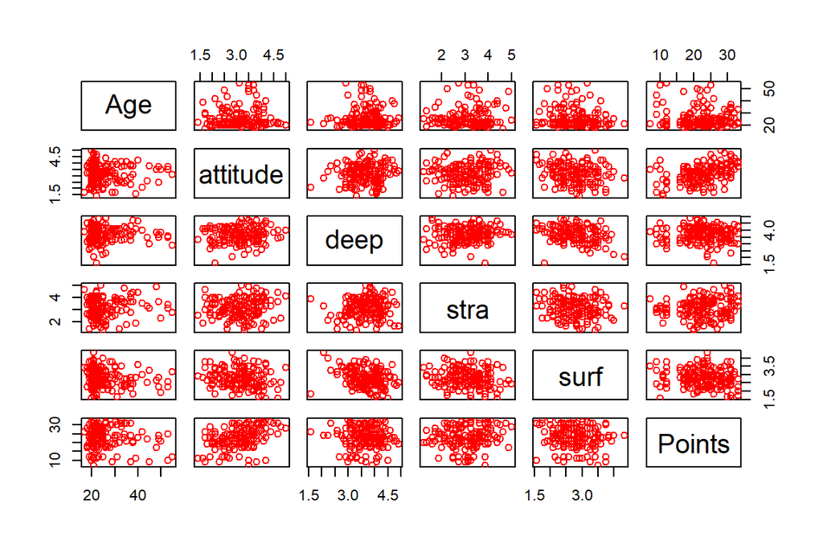

```r
pairs(learningAnalysis2014[-1], col = "red")

library(ggplot2)
```

```r
library(GGally)
```

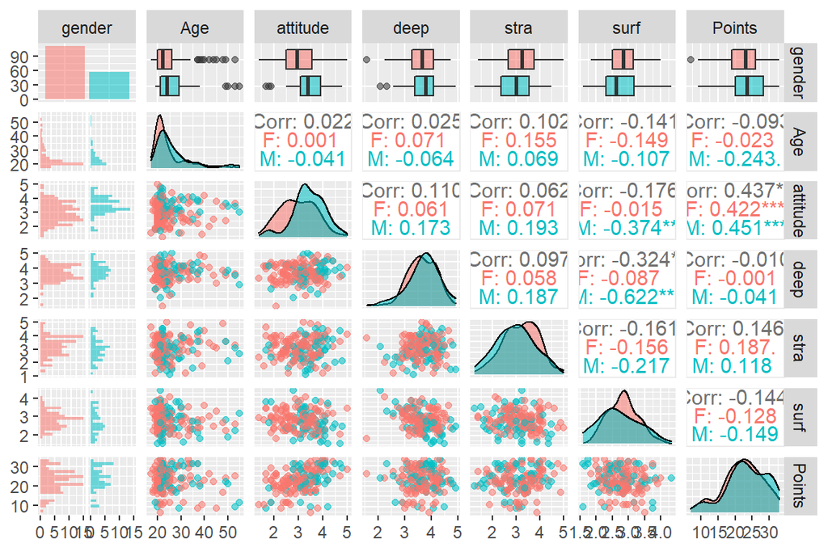

```r
ggpairs(learningAnalysis2014, mapping = aes(col = gender, alpha = 0.3), lower = list(combo = wrap("facethist", bins = 20)))
```